# Breakpoint Troubleshooting and Debugging with RStudio

Archit Gupta

October 22, 2016

## Setting breakpoints

##### Nothing happens when clicking in the gutter

Breakpoints cannot be set anywhere; the most likely cause of this problem is that you’re trying to set a breakpoint on a line that doesn’t support breakpoints. Lines on which you can set breakpoints are those which:

- are in R code (.R file);
- contain an R statement (i.e. are not just comments or whitespace); and
- are a top-level expression or a simple, named function

The most common (and easiest) way to stop on a line of code is to set a breakpoint on that line. You can do this in RStudio by clicking to the left of the line number in the editor, or by pressing *Shift+F9* with your cursor on the desired line.

##### A warning bar appears when setting a breakpoint

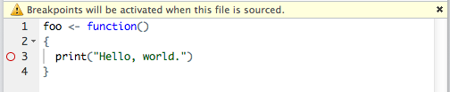

The circle outline indicates that RStudio will remember the breakpoint, but the breakpoint has not yet been enabled. You need to take further action to enable it.

If this happens, the following should enable the breakpoint.

- Save the file
- Source the file (by pressing the Source button in the toolbar). If developing a package, rebuild and reload the package.

## Hitting breakpoints

If the code on which you’re setting a breakpoint is executing but the breakpoint is not being hit, it’s possible that the type of code does not yet support breakpoints. Here are two common cases:

##### Complex function assignments

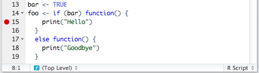

RStudio understands function assignments of the form:

name <- function(args, …)

It does not understand more complex syntax.

In this case, the editor indicates that the current function is (Top Level) even when the cursor is inside foo. Because the editor does not know which function to place the breakpoint in, the breakpoint on line 15 in this example won’t work.

##### Anonymous expressions

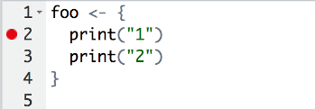

Code inside anonymous expressions is also immune to breakpoints, and for the same reason-the expression is neither a named function nor a top-level statement that can be stepped through as the file is sourced.

### browser() breakpoints

If you need a breakpoint in these cases, add the statement browser() to create one manually.

The R function browser() halts execution and invokes an environment browser when it is called. You can put browser() anywhere in your code to stop at that point in the code for debugging. Here, for instance, it’s used to halt when a function is about to return TRUE:

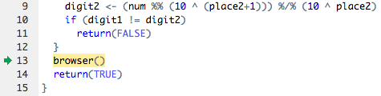

The browser() statement is actually part of your code, so it needs to be applied like any other code change in order to become active (by sourcing the containing document, rebuilding the containing package, reloading the Shiny application, etc.).

The environment browser invoked by browser() is the same one used in all of the other debugging facilities, so it can be considered the lowest-level debugging tool. Because the browser() statement requires no special tooling, it can be used in contexts where editor breakpoints won’t work.

browser() is also useful for creating conditional breakpoints. For instance, if you want to start debugging after hundreds of loop iterations:

```r
for (i in 1:1024) {
  start_work()
  if (i == 512)
    browser()
  finish_work()
}
```

### Stopping when a function executes

If you have the .R file corresponding to the code you want to debug, it’s easy to use editor breakpoints or browser() to add breakpoints to it. Sometimes, however, you don’t have the source file for the code you want to debug.

When this is the case, you can set a debug flag on the function you want to debug. You can think of this as setting a breakpoint before the very first statement in a function; it does not change the function itself, but it causes the debugger to activate immediately when the function is run.

Use the R function debugonce() to set the debug flag on a function. For instance, if you want to debug devtools::install():

```r
debugonce(devtools::install)
```

debugonce() sets a one-shot breakpoint-that is, the function will enter the debugger the very next time it runs, but not after that. If you want to debug a function every time it executes, call debug(…) on the function. Call undebug(…) on the function when you no longer want to debug the function each time it executes. We don’t recommend this pattern, since it can leave you trapped in the debugger for some special functions.

### Stopping when an error occurs

If you’re diagnosing a specific error, you can have RStudio halt execution at the point where the error is raised. To do this, go to Debug -> On Error and change the value from “Error Inspector” to “Break in Code”.

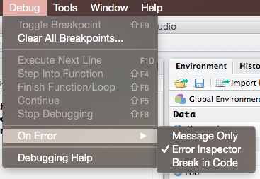

To keep the the debugger from being invoked whenever any error anywhere happens, RStudio does not invoke the debugger if it looks like none of your own code is on the stack. If you find that this is excluding an error you want to catch, go to Tools -> Global Options and uncheck “Use debug error handler only when my code contains errors”.

If you really want to invoke the debugger on every error, always, this will do the job:

```r
options(error = browser())
```

This overrides RStudio’s error handler settings. Trapping every error will quickly become annoying, though, so be sure to use the Debug menu to change the error option back when you’re done troubleshooting (or turn off error handling entirely with:

```r
options(error = NULL)
```

### Using the debugger

Once your code is stopped, the IDE will automatically enter debug mode, in which a variety of tools for inspecting and altering the state of your program become available. We’ll look at each in turn.

[figure not shown]

#### Environment pane

Usually in R you’re interacting with the “global environment”, a list of named objects such as values, functions, and data. When you enter debug mode, the IDE begins viewing and interacting with the currently executing function’s environment instead. That means that the objects you see in the Environment pane belong to the currently executing function, and statements you enter in the Console will be evaluated in the context of the function.

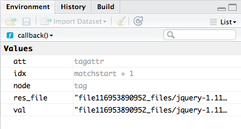

The gray values are promises-in this case, function arguments that haven’t been evaluated yet.

Above the list of local objects in the Environment pane is a drop-list that shows you the “environment stack”. This shows you the inheritance chain for the active environment-that is, the list of places that will be searched to resolve variable names to values.

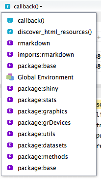

Most of the time it will include just the current function, the global environment, and some package namespaces, but if you’re writing a package or nesting functions, it’ll have additional entries. You can click any item in the droplist to see the contents of the corresponding environment.

If this all sounds confusing, don’t worry-most of the time you won’t need to dive into the environment stack! If you want to understand what’s going on under the covers, see Environments for a detailed look at how environments and inheritance work.

**Traceback (Callstack)**

The traceback shares space with the environment pane. It shows you how execution reached the current point, from the first function that was run (at the bottom) to the function that is running now (at the top).

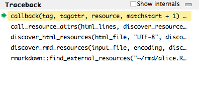

This is called the “call stack” in most languages; RStudio refers to it as the “traceback” for symmetry with the R command traceback().

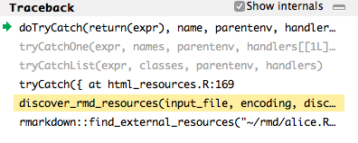

**Code window**

The code window shows you the currently executing function. The line about to execute is highlighted in yellow.

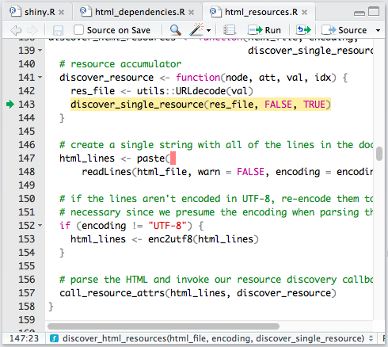

If RStudio can’t find a .R file that matches the function, it will show the code in the Source Viewer. This can happen either because no .R file exists or because the function object doesn’t match the definition in the .R file.

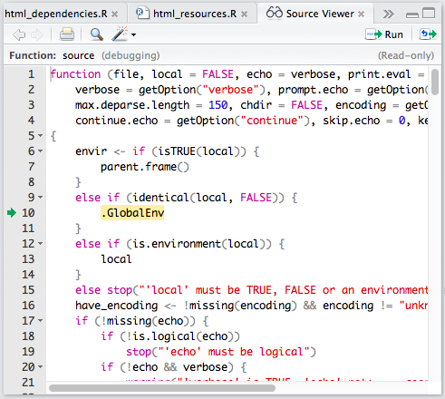

**Console**

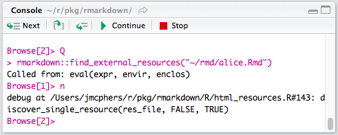

While debugging, you’ll notice two changes to the R console. The first is that the prompt is different:

```r
Browse[1]>
```

This prompt indicates that you’re inside the R environment browser.

### Debugging outside functions

You might have noticed earlier that RStudio (and R itself, via setBreakpoint()) creates breakpoints by modifying the function in which a breakpoint is set. What happens when you set a breakpoint outside a function?

The most common use case here is halting during execution of a source() command, to examine the state during execution of an R script. R’s built-in source() command doesn’t have a way to do this, but RStudio includes its own version of source() called debugSource() that does. This version is able to halt at the breakpoints RStudio knows about.

Consequently, if a file contains breakpoints outside functions, you’ll need to call debugSource() in place of source() on that file. RStudio does this for you automatically when the file contains breakpoints and you use the RStudio Source command to source your script.

It’s important to note that debugSource is not recursive. This implies that if you call source(“file1.R”) inside file2.R, then execute the whole thing with debugSource(“file2.R”), you’ll hit breakpoints in file2.R, but not file1.R. We generally recommend that you isolate code for debugging, but if you need to work this way, you can call debugSource manually inside your R script.

### Debugging in R Markdown documents

Breakpoints don’t currently work inside R chunks in R Markdown documents, so you’ll need to use browser() to halt execution in a chunk if needed.

By default, RStudio renders R Markdown documents using a separate R process when you click the Knit button. This has many benefits; it keeps the document reproducible by isolating it from your current session’s state, and it keeps the UI and console responsive while the document renders. However, debugging only works with the primary R process, so when rendering the document for debugging, you’ll need to ensure it renders there.

To do this, call rmarkdown::render() directly on your file:

```r
rmarkdown::render("~/mydocs/doc.Rmd")
```

Finally, because R Markdown chunks don’t contain source references, most of the debugger’s visual features are disabled; you won’t see the active line highlighting in the editor and most debugging will need to be done in the console.

### Reference:

- https://support.rstudio.com/hc/en-us/articles/205612627-Debugging-with-RStudio.
- Advanced R , Hadley Wickham